# Doodle_challenge_v2

### Volume analysis

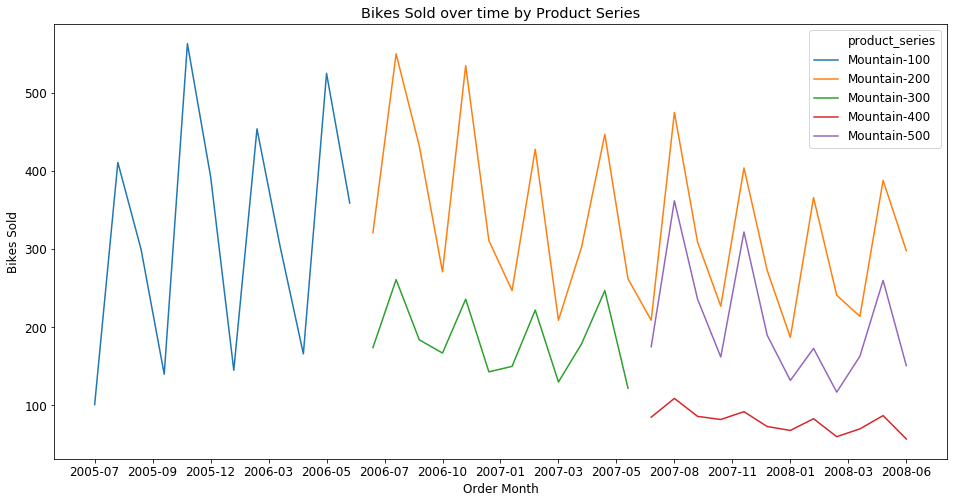

```python
### Average price of Mountain 200, 400 and 500 has not changed in 2008 at all
plot_variable_over_time(mountain_monthly_bikes_series_view, 'items_ordered_sum', 'Bikes Sold',
                        'product_series', 'Product Series')
```

```python
rolling_test_mb = mountain_monthly_bikes_series_view.sort_values(by=['product_series', 'order_month'], ascending = True)
rolling_test_mb['items_sold_rolling'] = rolling_test_mb.groupby(['product_series'])['items_ordered_sum'].rolling(3).mean().values
rolling_test_mb[['product_series','order_month','items_ordered_sum', 'items_sold_rolling']]
```

|  | product_series | order_month | items_ordered_sum | items_sold_rolling |
| --- | --- | --- | --- | --- |
| 0 | Mountain-100 | 2005-07 | 101 | NaN |
| 4 | Mountain-100 | 2005-08 | 411 | NaN |
| 8 | Mountain-100 | 2005-09 | 300 | 270.666667 |
| 12 | Mountain-100 | 2005-10 | 140 | 283.666667 |
| 16 | Mountain-100 | 2005-11 | 563 | 334.333333 |
| ... | ... | ... | ... | ... |
| 180 | Mountain-500 | 2008-02 | 173 | 165.000000 |
| 190 | Mountain-500 | 2008-03 | 117 | 140.666667 |
| 200 | Mountain-500 | 2008-04 | 163 | 151.000000 |
| 210 | Mountain-500 | 2008-05 | 260 | 180.000000 |
| 220 | Mountain-500 | 2008-06 | 151 | 191.333333 |

72 rows × 4 columns

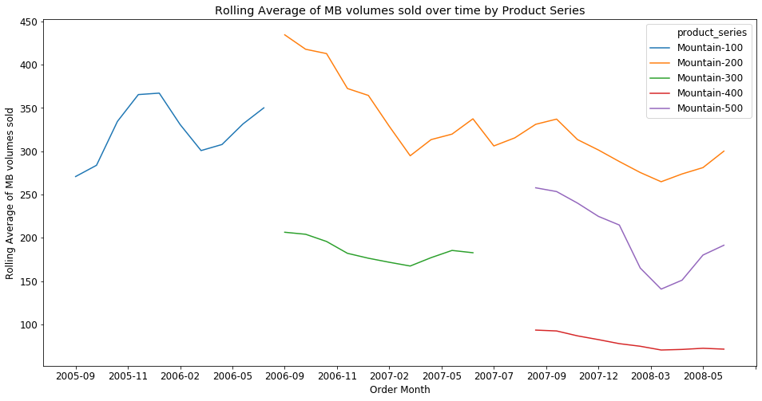

```python
### Average price of Mountain 200, 400 and 500 has not changed in 2008 at all
plot_variable_over_time(rolling_test_mb, 'items_sold_rolling', 'Rolling Average of MB volumes sold',
                        'product_series', 'Product Series')
```

```python
rolling_test_road = road_monthly_bikes_series_view.sort_values(by=['product_series', 'order_month'], ascending = True)
rolling_test_road['items_sold_rolling'] = rolling_test_road.groupby(['product_series'])['items_ordered_sum'].rolling(3).mean().values
rolling_test_road[['product_series','order_month','items_ordered_sum', 'items_sold_rolling']]
```

|  | product_series | order_month | items_ordered_sum | items_sold_rolling |
| --- | --- | --- | --- | --- |
| 1 | Road-150 | 2005-07 | 12 | NaN |
| 5 | Road-150 | 2005-08 | 33 | NaN |
| 9 | Road-150 | 2005-09 | 31 | 25.333333 |
| 13 | Road-150 | 2005-10 | 60 | 41.333333 |
| 17 | Road-150 | 2005-11 | 128 | 73.000000 |
| ... | ... | ... | ... | ... |
| 184 | Road-750 | 2008-02 | 203 | 174.000000 |
| 194 | Road-750 | 2008-03 | 154 | 162.333333 |
| 204 | Road-750 | 2008-04 | 138 | 165.000000 |
| 214 | Road-750 | 2008-05 | 214 | 168.666667 |
| 224 | Road-750 | 2008-06 | 191 | 181.000000 |

120 rows × 4 columns

```python
rolling_test_road[['product_series','order_month']].values
```

```
array([['Road-150', '2005-07'],
       ['Road-150', '2005-08'],
       ['Road-150', '2005-09'],
       ['Road-150', '2005-10'],
       ['Road-150', '2005-11'],
       ['Road-150', '2005-12'],
       ['Road-150', '2006-01'],
       ['Road-150', '2006-02'],
       ['Road-150', '2006-03'],
       ['Road-150', '2006-04'],
       ['Road-150', '2006-05'],
       ['Road-150', '2006-06'],
       ['Road-250', '2006-07'],
       ['Road-250', '2006-08'],
       ['Road-250', '2006-09'],
       ['Road-250', '2006-10'],
       ['Road-250', '2006-11'],
       ['Road-250', '2006-12'],
       ['Road-250', '2007-01'],
       ['Road-250', '2007-02'],
       ['Road-250', '2007-03'],
       ['Road-250', '2007-04'],
       ['Road-250', '2007-05'],
       ['Road-250', '2007-06'],
       ['Road-250', '2007-07'],
       ['Road-250', '2007-08'],
       ['Road-250', '2007-09'],
       ['Road-250', '2007-10'],
       ['Road-250', '2007-11'],
       ['Road-250', '2007-12'],
       ['Road-250', '2008-01'],
       ['Road-250', '2008-02'],
       ['Road-250', '2008-03'],
       ['Road-250', '2008-04'],
       ['Road-250', '2008-05'],
       ['Road-250', '2008-06'],
       ['Road-350', '2007-07'],
       ['Road-350', '2007-08'],
       ['Road-350', '2007-09'],
       ['Road-350', '2007-10'],
```

[output cut: 65 more lines]

```
       ['Road-650', '2007-04'],
       ['Road-650', '2007-05'],
       ['Road-650', '2007-06'],
       ['Road-750', '2007-07'],
       ['Road-750', '2007-08'],
       ['Road-750', '2007-09'],
       ['Road-750', '2007-10'],
       ['Road-750', '2007-11'],
       ['Road-750', '2007-12'],
       ['Road-750', '2008-01'],
       ['Road-750', '2008-02'],
       ['Road-750', '2008-03'],
       ['Road-750', '2008-04'],
       ['Road-750', '2008-05'],
       ['Road-750', '2008-06']], dtype=object)
```

```python
rolling_test_road = rolling_test_road.sort_values(by='order_month', ascending = True)
```

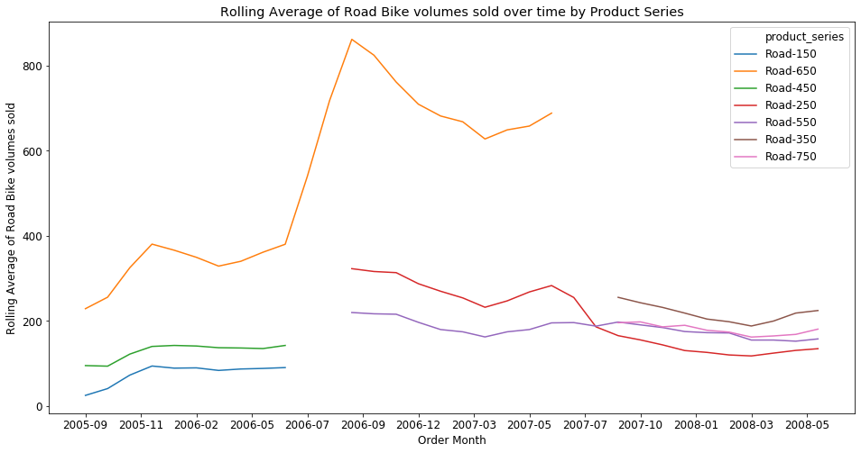

```python
### Average price of Mountain 200, 400 and 500 has not changed in 2008 at all
plot_variable_over_time(rolling_test_road, 'items_sold_rolling', 'Rolling Average of Road Bike volumes sold',
                        'product_series', 'Product Series')
# plt.savefig()
```

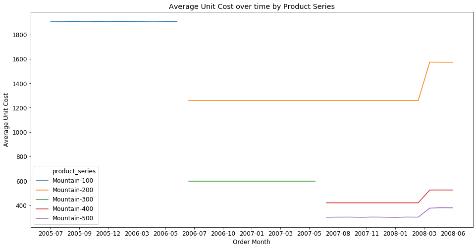

```python
### Average price of Mountain 200, 400 and 500 has not changed in 2008 at all
plot_variable_over_time(mountain_monthly_bikes_series_view, 'unit_cost_mean', 'Average Unit Cost',
                        'product_series', 'Product Series')
```

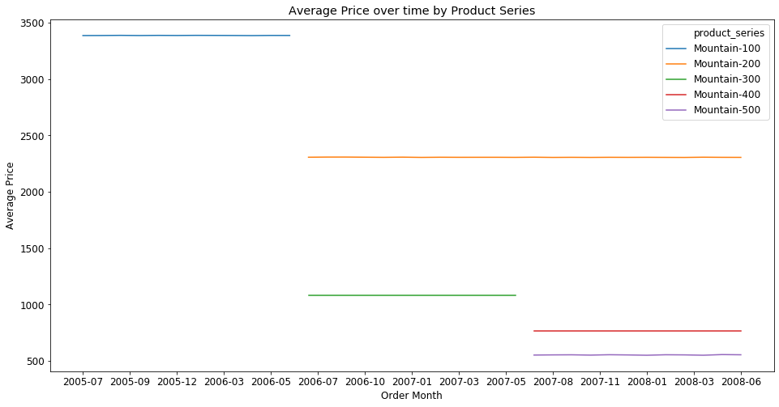

```python
### Average price of Mountain 200, 400 and 500 has not changed in 2008 at all
plot_variable_over_time(mountain_monthly_bikes_series_view, 'unit_price_mean', 'Average Price',
                        'product_series', 'Product Series')
```

#### Images attached to the presentation were taken as screenshots rather than first saved as images to save time. ### The quality of the images can be improved and the work be better organized if time allows for images to be saved

```python
road_monthly_bikes_series_view = monthly_bikes_series_view.loc[monthly_bikes_series_view['product_series'].str.contains('Road')]
```

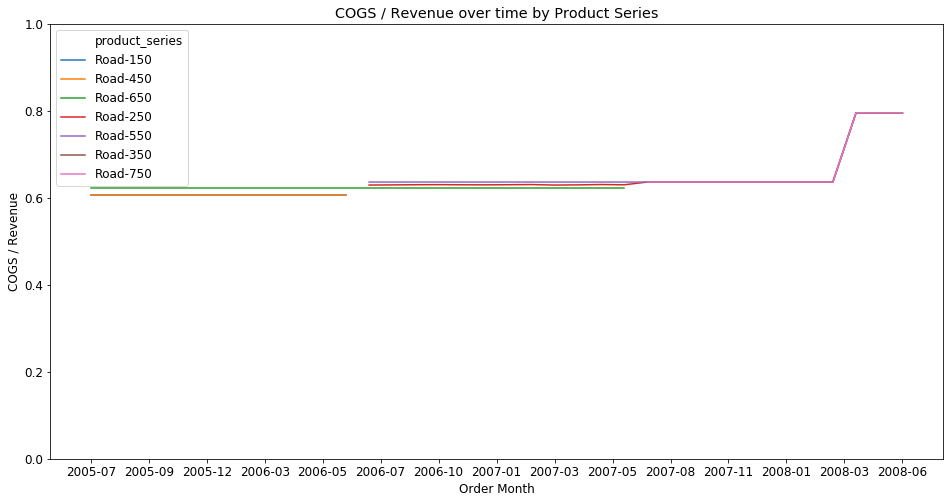

```python
plot_variable_over_time(road_monthly_bikes_series_view, 'cogs/revenue', 'COGS / Revenue',
                        'product_series', 'Product Series', variable_type = 'percentual')
```

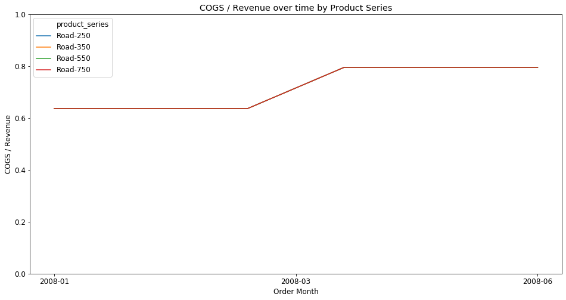

```python
plot_variable_over_time(road_monthly_bikes_series_view.loc[road_monthly_bikes_series_view['order_month']>='2008-01'],
                        'cogs/revenue', 'COGS / Revenue',
                        'product_series', 'Product Series', variable_type = 'percentual')
```

```python
touring_monthly_bikes_series_view = monthly_bikes_series_view.loc[monthly_bikes_series_view['product_series'].str.contains('Touring')]
```

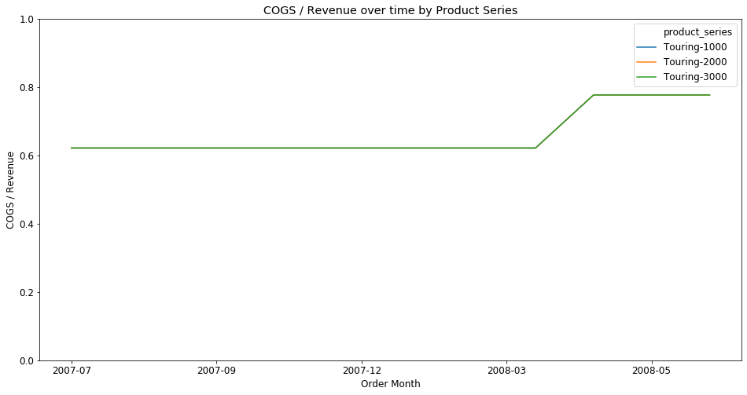

```python
plot_variable_over_time(touring_monthly_bikes_series_view, 'cogs/revenue', 'COGS / Revenue',
                        'product_series', 'Product Series', variable_type = 'percentual')
```

```python
## Does each subgroup have all months  manual-check
np.array(monthly_product_view[['product_category_rec', 'order_month']].drop_duplicates())
```

```
array([['Bikes', '2005-07'],
       ['Extras', '2005-07'],
       ['Bikes', '2005-08'],
       ['Extras', '2005-08'],
       ['Bikes', '2005-09'],
       ['Extras', '2005-09'],
       ['Bikes', '2005-10'],
       ['Extras', '2005-10'],
       ['Bikes', '2005-11'],
       ['Extras', '2005-11'],
       ['Bikes', '2005-12'],
       ['Extras', '2005-12'],
       ['Bikes', '2006-01'],
       ['Extras', '2006-01'],
       ['Bikes', '2006-02'],
       ['Extras', '2006-02'],
       ['Bikes', '2006-03'],
       ['Extras', '2006-03'],
       ['Bikes', '2006-04'],
       ['Extras', '2006-04'],
       ['Bikes', '2006-05'],
       ['Extras', '2006-05'],
       ['Bikes', '2006-06'],
       ['Extras', '2006-06'],
       ['Bikes', '2006-07'],
       ['Extras', '2006-07'],
       ['Bikes', '2006-08'],
       ['Extras', '2006-08'],
       ['Bikes', '2006-09'],
       ['Extras', '2006-09'],
       ['Bikes', '2006-10'],
       ['Extras', '2006-10'],
       ['Bikes', '2006-11'],
       ['Extras', '2006-11'],
       ['Bikes', '2006-12'],
       ['Extras', '2006-12'],
       ['Bikes', '2007-01'],
       ['Extras', '2007-01'],
       ['Bikes', '2007-02'],
       ['Extras', '2007-02'],
```

[output cut: 17 more lines]

```
       ['Extras', '2007-11'],
       ['Bikes', '2007-12'],
       ['Extras', '2007-12'],
       ['Bikes', '2008-01'],
       ['Extras', '2008-01'],
       ['Bikes', '2008-02'],
       ['Extras', '2008-02'],
       ['Bikes', '2008-03'],
       ['Extras', '2008-03'],
       ['Bikes', '2008-04'],
       ['Extras', '2008-04'],
       ['Bikes', '2008-05'],
       ['Extras', '2008-05'],
       ['Bikes', '2008-06'],
       ['Extras', '2008-06']], dtype=object)
```

```python
monthly_product_view.loc[monthly_product_view['product_category_rec']=='Bikes']
```

|  | order_month | product_category_rec | items_ordered_mean | items_ordered_sum | unique_orders | revenue_mean | revenue_sum | final_revenue_mean | final_revenue_sum | order_cost_mean | ... | order_freight_cost_sum_delta_pct | order_margin_1_sum_delta | order_margin_1_sum_delta_pct | order_margin_2_sum_delta | order_margin_2_sum_delta_pct | order_discount_sum | cogs/revenue | cogs/final_revenue | order_cm1% | order_cm2% |
| --- | --- | --- | --- | --- | --- | --- | --- | --- | --- | --- | --- | --- | --- | --- | --- | --- | --- | --- | --- | --- | --- |
| 0 | 2005-07 | Bikes | 2.183007 | 334 | 153 | 3940.549150 | 602904.02 | 3940.549150 | 602904.02 | 2303.629525 | ... | NaN | NaN | NaN | NaN | NaN | 0.00 | 0.584596 | 0.584596 | 0.415404 | 0.388445 |
| 2 | 2005-08 | Bikes | 2.584098 | 845 | 327 | 5803.005474 | 1897582.79 | 5794.915260 | 1894937.29 | 3342.613513 | ... | 2.797482 | 551453.968400 | 2.201864 | 505983.886700 | 2.160526 | -2645.50 | 0.576014 | 0.576818 | 0.422592 | 0.390064 |
| 4 | 2005-09 | Bikes | 2.583333 | 682 | 264 | 5592.150985 | 1476327.86 | 5589.338485 | 1475585.36 | 3232.969030 | ... | -0.256516 | -179821.134900 | -0.224243 | -163987.940200 | -0.221552 | -742.50 | 0.578126 | 0.578417 | 0.421371 | 0.390286 |
| 6 | 2005-10 | Bikes | 2.243243 | 498 | 222 | 4345.048739 | 964600.82 | 4345.048739 | 964600.82 | 2554.032711 | ... | -0.363177 | -224475.978100 | -0.360847 | -207809.482800 | -0.360661 | 0.00 | 0.587803 | 0.587803 | 0.412197 | 0.381900 |
| 8 | 2005-11 | Bikes | 2.678917 | 1385 | 517 | 5879.464197 | 3039682.99 | 5876.461296 | 3038130.49 | 3415.065368 | ... | 2.766288 | 874936.136900 | 2.200513 | 794093.230700 | 2.155629 | -1552.50 | 0.580846 | 0.581143 | 0.418643 | 0.382433 |
| 10 | 2005-12 | Bikes | 2.958101 | 1059 | 358 | 6224.983268 | 2228544.01 | 6222.703939 | 2227728.01 | 3625.442669 | ... | -0.245596 | -342722.160600 | -0.269321 | -315690.055400 | -0.271567 | -816.00 | 0.582402 | 0.582615 | 0.417232 | 0.379972 |
| 12 | 2006-01 | Bikes | 2.112150 | 452 | 214 | 4227.519065 | 904689.08 | 4227.519065 | 904689.08 | 2473.727735 | ... | -0.598954 | -554508.189600 | -0.596361 | -504773.946600 | -0.596107 | 0.00 | 0.585149 | 0.585149 | 0.414851 | 0.378042 |
| 14 | 2006-02 | Bikes | 2.467742 | 1224 | 496 | 5306.772500 | 2632159.16 | 5306.772500 | 2632159.16 | 3093.021271 | ... | 2.053656 | 722709.264600 | 1.925626 | 654320.699200 | 1.913160 | 0.00 | 0.582844 | 0.582844 | 0.417156 | 0.378522 |
| 16 | 2006-03 | Bikes | 2.456583 | 877 | 357 | 5023.164678 | 1793269.79 | 5023.164678 | 1793269.79 | 2931.652087 | ... | -0.380705 | -351350.614600 | -0.319985 | -312636.975200 | -0.313788 | 0.00 | 0.583627 | 0.583627 | 0.416373 | 0.381256 |
| 18 | 2006-04 | Bikes | 2.309417 | 515 | 223 | 4641.826233 | 1035127.25 | 4641.826233 | 1035127.25 | 2716.463890 | ... | -0.527765 | -317314.192200 | -0.424972 | -284077.790800 | -0.415504 | 0.00 | 0.585214 | 0.585214 | 0.414786 | 0.386055 |
| 20 | 2006-05 | Bikes | 2.685771 | 1359 | 506 | 5793.875356 | 2931700.93 | 5791.934130 | 2930718.67 | 3371.430828 | ... | 2.442614 | 795418.868400 | 1.852587 | 722776.990700 | 1.808677 | -982.26 | 0.581896 | 0.582091 | 0.417769 | 0.382847 |
| 22 | 2006-06 | Bikes | 2.726542 | 1017 | 373 | 5576.774987 | 2080137.07 | 4434.722949 | 1654151.66 | 3251.761767 | ... | -0.444154 | -783530.150000 | -0.639734 | -738057.047200 | -0.657574 | -425985.41 | 0.583090 | 0.733250 | 0.212123 | 0.184765 |
| 24 | 2006-07 | Bikes | 4.130435 | 1615 | 391 | 5782.729898 | 2261047.39 | 5711.439974 | 2233173.03 | 3437.247935 | ... | 0.446130 | 447964.566600 | 1.015230 | 422576.125700 | 1.099496 | -27874.36 | 0.594399 | 0.601818 | 0.393273 | 0.356876 |
| 26 | 2006-08 | Bikes | 3.529655 | 2559 | 725 | 5131.640372 | 3720439.27 | 5086.635117 | 3687810.46 | 3048.466882 | ... | 0.399247 | 588462.882700 | 0.661782 | 555606.166800 | 0.688558 | -32628.81 | 0.594053 | 0.599309 | 0.397177 | 0.366225 |
| 28 | 2006-09 | Bikes | 4.165605 | 1962 | 471 | 5997.840382 | 2824982.82 | 5970.982144 | 2812332.59 | 3559.782662 | ... | -0.131313 | -341997.014200 | -0.231443 | -326875.890100 | -0.239906 | -12650.23 | 0.593511 | 0.596180 | 0.402011 | 0.366601 |
| 30 | 2006-10 | Bikes | 3.614796 | 1417 | 392 | 5081.356301 | 1991891.67 | 5076.103010 | 1989832.38 | 3025.180161 | ... | -0.259847 | -331713.199200 | -0.292085 | -305720.079200 | -0.295198 | -2059.29 | 0.595349 | 0.595965 | 0.403617 | 0.366447 |
| 32 | 2006-11 | Bikes | 3.331897 | 2319 | 696 | 5009.118233 | 3486346.29 | 5008.318233 | 3485789.49 | 2973.076120 | ... | 0.486411 | 612566.753600 | 0.761935 | 576553.303600 | 0.789883 | -556.80 | 0.593533 | 0.593628 | 0.406307 | 0.374741 |
| 34 | 2006-12 | Bikes | 3.287582 | 1509 | 459 | 4629.931961 | 2125138.77 | 4622.551373 | 2121751.08 | 2751.911691 | ... | -0.407094 | -557904.896600 | -0.393854 | -513103.150100 | -0.392738 | -3387.69 | 0.594374 | 0.595323 | 0.404032 | 0.373328 |
| 36 | 2007-01 | Bikes | 3.266484 | 1189 | 364 | 4578.149368 | 1666446.37 | 4575.026291 | 1665309.57 | 2711.517502 | ... | 0.082057 | -180306.414700 | -0.209995 | -185660.679500 | -0.234014 | -1136.80 | 0.592274 | 0.592678 | 0.407044 | 0.364675 |
| 38 | 2007-02 | Bikes | 3.074890 | 2094 | 681 | 4493.127195 | 3059819.62 | 4490.959266 | 3058343.26 | 2677.144678 | ... | 0.740029 | 556890.535000 | 0.820988 | 504640.730400 | 0.830394 | -1476.36 | 0.595831 | 0.596119 | 0.403686 | 0.363535 |
| 40 | 2007-03 | Bikes | 3.073491 | 1171 | 381 | 4144.801549 | 1579169.39 | 4143.732887 | 1578762.23 | 2468.425730 | ... | -0.555342 | -596915.707200 | -0.483251 | -528689.260800 | -0.475289 | -407.16 | 0.595547 | 0.595701 | 0.404195 | 0.369602 |
| 42 | 2007-04 | Bikes | 3.724409 | 1419 | 381 | 5320.893097 | 2027260.27 | 5311.576325 | 2023710.58 | 3151.434392 | ... | 0.255658 | 184722.049500 | 0.289401 | 170755.839800 | 0.292559 | -3549.69 | 0.592275 | 0.593314 | 0.405974 | 0.372137 |
| 44 | 2007-05 | Bikes | 3.329377 | 2244 | 674 | 4931.563501 | 3323873.80 | 4929.854481 | 3322721.92 | 2943.338132 | ... | 0.544786 | 515897.942200 | 0.626840 | 478528.540900 | 0.634300 | -1151.88 | 0.596837 | 0.597044 | 0.402817 | 0.370937 |
| 46 | 2007-06 | Bikes | 3.315166 | 1399 | 422 | 4564.584858 | 1926254.81 | 4557.305095 | 1923182.75 | 2723.858009 | ... | -0.455279 | -565197.348400 | -0.422132 | -516954.129100 | -0.419283 | -3072.06 | 0.596737 | 0.597691 | 0.401668 | 0.371703 |
| 48 | 2007-07 | Bikes | 3.656455 | 1671 | 457 | 5252.167768 | 2400240.67 | 5065.432035 | 2314902.44 | 3187.468081 | ... | 0.573115 | 84514.856500 | 0.109233 | 51434.195900 | 0.071836 | -85338.23 | 0.606886 | 0.629259 | 0.357560 | 0.319730 |
| 50 | 2007-08 | Bikes | 3.380587 | 2647 | 783 | 4966.951865 | 3889123.31 | 4826.114202 | 3778847.42 | 2980.530115 | ... | 0.461892 | 586862.812800 | 0.683806 | 544922.369500 | 0.710063 | -110275.89 | 0.600072 | 0.617584 | 0.371573 | 0.337441 |
| 52 | 2007-09 | Bikes | 3.089286 | 2249 | 728 | 4485.007679 | 3265085.59 | 4317.696717 | 3143283.21 | 2715.964480 | ... | -0.239730 | -279031.270800 | -0.193089 | -247209.028300 | -0.188371 | -121802.38 | 0.605565 | 0.629031 | 0.357130 | 0.326222 |
| 54 | 2007-10 | Bikes | 3.228571 | 1469 | 455 | 4724.827495 | 2149796.51 | 4692.662967 | 2135161.65 | 2848.955742 | ... | -0.249636 | -327174.281500 | -0.280581 | -301981.108700 | -0.283513 | -14634.86 | 0.602976 | 0.607109 | 0.390217 | 0.354992 |
| 56 | 2007-11 | Bikes | 3.037940 | 2242 | 738 | 4425.868943 | 3266291.28 | 4419.487656 | 3261581.89 | 2654.484935 | ... | 0.466007 | 463685.220800 | 0.552739 | 428396.139100 | 0.561345 | -4709.39 | 0.599766 | 0.600632 | 0.398792 | 0.364804 |
| 58 | 2007-12 | Bikes | 2.627972 | 1879 | 715 | 3779.185385 | 2702117.55 | 3771.434601 | 2696575.74 | 2284.608879 | ... | -0.292397 | -239491.616700 | -0.183861 | -207031.039700 | -0.173748 | -5541.81 | 0.604524 | 0.605767 | 0.393425 | 0.364353 |
| 60 | 2008-01 | Bikes | 2.870588 | 1220 | 425 | 4122.787153 | 1752184.54 | 4117.644118 | 1749998.75 | 2485.407911 | ... | -0.218153 | -369380.003700 | -0.347462 | -352242.987000 | -0.357779 | -2185.79 | 0.602847 | 0.603599 | 0.395906 | 0.360854 |
| 62 | 2008-02 | Bikes | 2.831858 | 1920 | 678 | 4228.785369 | 2867116.48 | 4223.352773 | 2863433.18 | 2541.445140 | ... | 0.857582 | 446632.987200 | 0.643841 | 393962.004000 | 0.623079 | -3683.30 | 0.600987 | 0.601760 | 0.397728 | 0.357936 |
| 64 | 2008-03 | Bikes | 2.507645 | 1640 | 654 | 3724.447584 | 2435788.72 | 3719.536590 | 2432576.93 | 2255.804585 | ... | -0.323589 | -183052.643500 | -0.160526 | -146134.675800 | -0.142398 | -3211.79 | 0.605675 | 0.606475 | 0.393006 | 0.361324 |
| 66 | 2008-04 | Bikes | 3.328638 | 1418 | 426 | 4819.106901 | 2052939.54 | 4802.398380 | 2045821.71 | 3634.809886 | ... | -0.034945 | -459888.033025 | -0.480411 | -457191.265625 | -0.519471 | -7117.83 | 0.754250 | 0.756874 | 0.242283 | 0.206006 |
| 68 | 2008-05 | Bikes | 2.991792 | 2187 | 731 | 4410.783406 | 3224282.67 | 4349.703707 | 3179633.41 | 3316.304667 | ... | 0.482003 | 258022.000250 | 0.518749 | 222125.214650 | 0.525220 | -44649.26 | 0.751863 | 0.762421 | 0.234289 | 0.200058 |
| 70 | 2008-06 | Bikes | 2.728341 | 1858 | 681 | 4088.073862 | 2783978.30 | 4047.565727 | 2756392.26 | 3087.139253 | ... | -0.251473 | -101364.269625 | -0.134184 | -73608.956925 | -0.114115 | -27586.04 | 0.755157 | 0.762715 | 0.234934 | 0.205258 |

36 rows × 34 columns

### Sales Regions by Month

```python
sales_by_regions = aggregate_grouped_df(df_1, ['order_month','sales_region'])
```

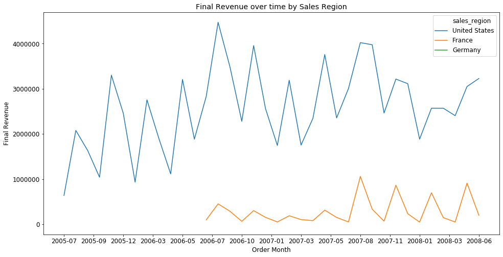

```python
plot_variable_over_time(sales_by_regions, 'final_revenue_sum', 'Final Revenue',
                        'sales_region', 'Sales Region')
```

### By far most Sales are in the US; focusing on sales provinces

```python
sales_by_provinces = aggregate_grouped_df(df_1, ['order_month','sales_province'])
```

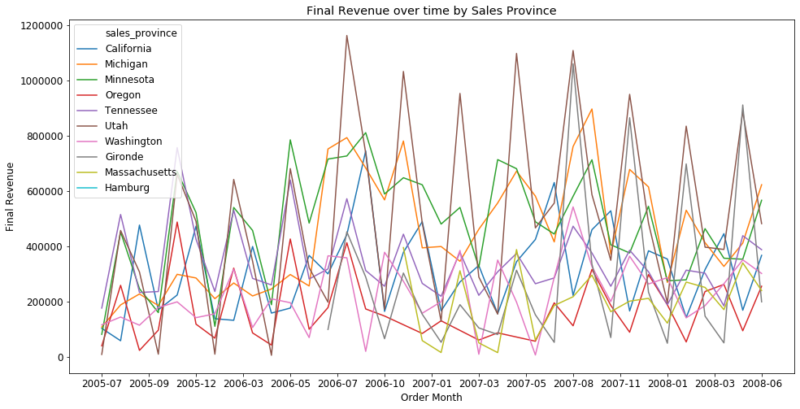

```python
plot_variable_over_time(sales_by_provinces, 'final_revenue_sum', 'Final Revenue',
                        'sales_province', 'Sales Province')
```

```python
### Most transactions happened in these 5 provinces
print(df_1['sales_province'].value_counts()[:5])
top_5_provinces = list(df_1['sales_province'].value_counts()[:5].index)
```

```
Minnesota     7825
Utah          7107
Michigan      7069
Tennessee     5417
California    4545
Name: sales_province, dtype: int64
```

```python
df_1['sales_province'].value_counts()
```

```
Minnesota        7825
Utah             7107
Michigan         7069
Tennessee        5417
California       4545
Washington       2986
Gironde          2977
Oregon           2064
Massachusetts    1893
Hamburg             1
Name: sales_province, dtype: int64
```

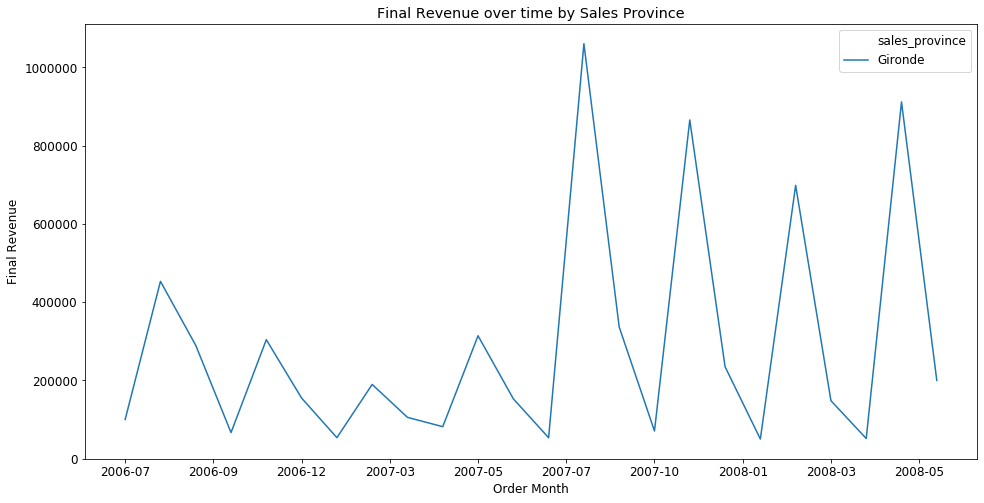

```python
### Looking at France only: great possibilities for further expansios in other French cities if revenue can reach this high
plot_variable_over_time(sales_by_provinces.loc[sales_by_provinces['sales_province']=='Gironde'],
                        'final_revenue_sum', 'Final Revenue',
                        'sales_province', 'Sales Province')
```

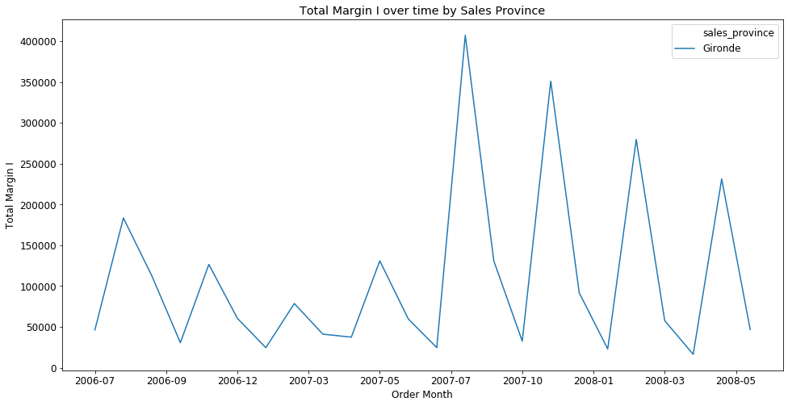

```python
### Looking at France only: great possibilities for further expansios in other French cities if revenue can reach this high
plot_variable_over_time(sales_by_provinces.loc[sales_by_provinces['sales_province']=='Gironde'],
                        'order_margin_1_sum', 'Total Margin I',
                        'sales_province', 'Sales Province')
```

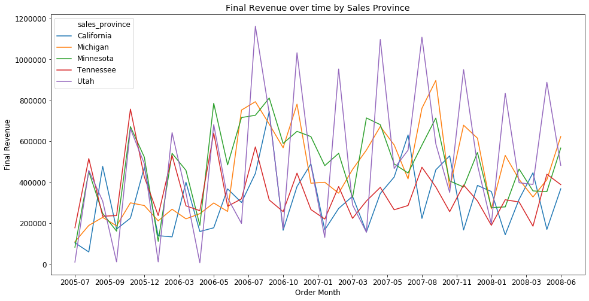

```python
plot_variable_over_time(sales_by_provinces.loc[sales_by_provinces['sales_province'].isin(top_5_provinces)],
                        'final_revenue_sum', 'Final Revenue',
                        'sales_province', 'Sales Province')
```

#### Still too messy to understand something

```python
sales_by_provinces = sales_by_provinces.sort_values(by=['sales_province', 'order_month'], ascending = True)
sales_by_provinces['items_sold_rolling'] = sales_by_provinces.groupby(['sales_province'])['items_ordered_sum'].rolling(3).mean().values
# sales_by_provinces[['product_series','order_month','items_ordered_sum', 'items_sold_rolling']]
```

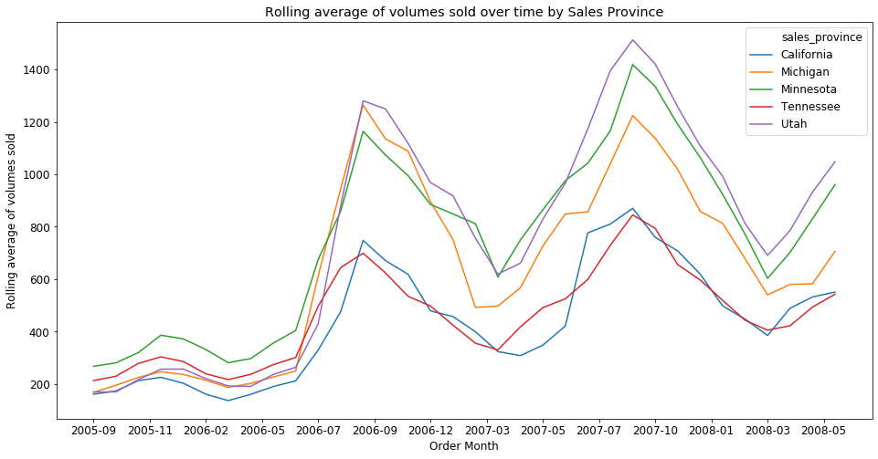

```python
plot_variable_over_time(sales_by_provinces.loc[sales_by_provinces['sales_province'].isin(top_5_provinces)],
                        'items_sold_rolling', 'Rolling average of volumes sold',
                        'sales_province', 'Sales Province')
```

### All top regions follow a similar pattern in sales. On first sight no reason to drill down further by province

#### We have to check for seasonality as the spikes are usually July to October and our current data is until June.

#### The decrease in Sales might as well be just temporary

# YoY check

```python
yoy_df = aggregate_grouped_df(df_1, ['order_year','order_month_no'])
```

```python
yoy_df = yoy_df.rename(columns={('order_year',''):'order_year',
                                'order_month_no':'order_month'})
```

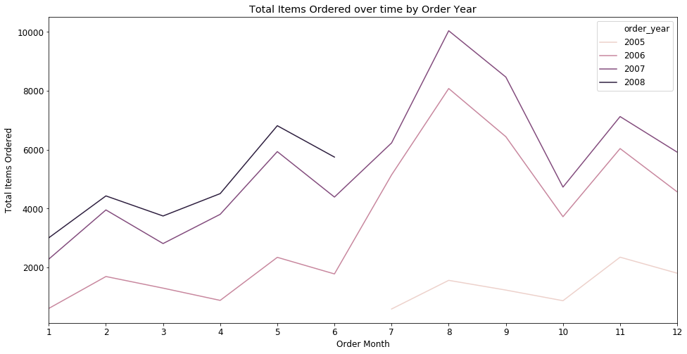

```python
plot_variable_over_time(yoy_df, 'items_ordered_sum', 'Total Items Ordered',
                        'order_year', 'Order Year')
```

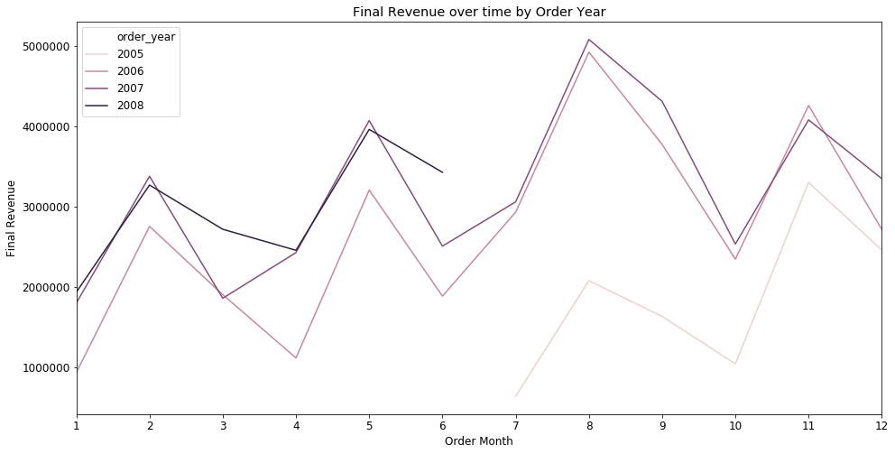

```python
plot_variable_over_time(yoy_df, 'final_revenue_sum', 'Final Revenue',
                        'order_year', 'Order Year')
```

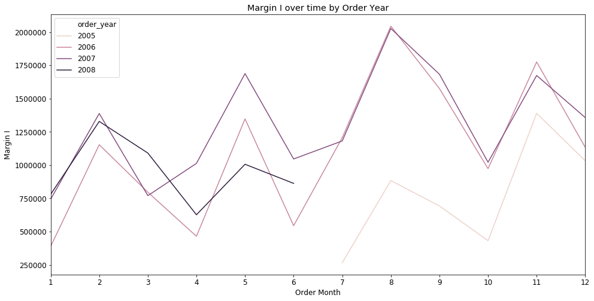

```python
plot_variable_over_time(yoy_df, 'order_margin_1_sum', 'Margin I',
                        'order_year', 'Order Year')
```

### Room for improvement given more time

#### a) Better choice of palette colors in graphs

#### b) Deeper Focus towards the city level and potential external data on market capacities

#### c) Analysis of freight cost development for France to check the economics behind expanding business to other countries i.e Australia

#### d) Future analyses should be easier if we can automate recategorizations done to this dataset in the View level of our database

#### e) Analysis of basket size using order_qty by unique sales_order_number over time